# R Notebook

Studio della funzione calinhara, quindi della metrica Calinski-Harabasz implementata al suo interno, tramite analisi di dataset artificiali. Viene utilizzata una matrice parametrica [2n, n].

Valutiamo tramite la metrica di Calinski-Harabasz il clustering effettuato con l’algoritmo K-means per un numero di clusters pari a 2.

CASO BASE

Si analizza come caso base da cui partire la situazione con la prima metà delle righe composta di soli 0 e la seconda metà composta di soli 1. Questa sarà la matrice base da cui partire e da modificare.

Il valore atteso dell’indice di Calinski-Harabasz sarà -> $inf$.

```r
library(fpc)

source("~/Calinski_Harabasz_Thesis/Script/FunzioniMatrice.R")

# CASO BASE: prima metà delle righe composta di soli 0 e la seconda metà
# composta di soli 1.

# Abilita/disabilita stampa
verbose <- FALSE

# Richiesta del parametro n per la matrice
n <- readInteger()
```

```
Inserisci un valore intero:
```

```r
20
```

```
Read 1 item
```

```r
if(verbose){
  print(n)
}
# Creazione e visualizzazione matrice
matrice <-creaMatrice(n)
if(verbose){
  matrice
}

# Clustering con K-means
cl <- kmeans(matrice, 2, , 100)

# Calcolo dell'indice di Calinski-Harabasz con calinhara
CH <- calinhara(matrice, cl$cluster)
cat(sprintf("\nValore indice Calinski-Harabasz: %f\n", CH))
```

```
Valore indice Calinski-Harabasz: Inf
```

CASO ITERATIVO

Si analizza iterativamente con un ciclo la situazione con la matrice base a cui viene modificata ad ogni passo una riga, presa casualmente tra quelle immutate, con valori compresi tra 0 e 1.

Il valore atteso dell’indice di Calinski-Harabasz sarà sicuramente inferiore al caso precedente e dipenderà anche dalla riga che viene sostituita e dai valori che la compongono. Ci aspettiamo quindi un valore che tenderà ad essere più vicino a $0$ che a $inf$.

```r
# CASO ITERATIVO: viene presa la matrice del caso precedente ed una riga scelta
#                 casualmente viene sostituita con valori compresi tra 0 e 1.



# Creazione dataframe iterazioni/valore
risultati <- data.frame(iterazione = integer(), valore = numeric(),
                        stringsAsFactors = FALSE)

# Creazione pool da cui estrarre la riga da modificare
n <- nrow(matrice) # Numero di righe della matrice
pool <- sample(1:n) # Crea un pool di numeri da 1 a n ordinato in modo casuale


# Ciclo iterativo per modifica di una riga alla volta
for (i in 1:nrow(matrice)) {
  if(verbose){
    cat(sprintf("\nIterazione %d:\n", i))
  }

  # Pesca un numero casualmente senza reimmissione dal pool creato
  selezione <- pool[i]
  if(verbose){
    cat(sprintf("\nRiga modificata: %d\n", selezione))
  }

  # Modifica riga della matrice
  matrice <- modificaRigaSelezionata(matrice, selezione)

  # Visualizzazione della matrice
  if(verbose){
    print(matrice)
  }

  # Clustering con K-means
  cl <- kmeans(matrice, 2, , 100)

  # Calcolo e visualizzazione dell'indice di Calinski-Harabasz con calinhara
  CH <- calinhara(matrice, cl$cluster)

  if(verbose){
    cat(sprintf("\nValore indice Calinski-Harabasz: %f\n", CH))
  }

  # Aggiornamento dataframe iterazioni/valore
  risultati <- rbind(risultati, data.frame(iterazione = i, valore = CH))

}
```

Possiamo quindi confrontare i valori ottenuti per ogni caso analizzato:

```r
library(ggplot2)

# Visualizzazione dei valori di Calinski-Harabasz per ogni matrice
print(risultati)
```

| iterazione | valore |
| --- | --- |
| 1 | 1223.303620 |
| 2 | 609.531336 |
| 3 | 444.087794 |
| 4 | 346.009912 |
| 5 | 275.666041 |
| 6 | 230.097571 |
| 7 | 192.336515 |
| 8 | 165.483939 |
| 9 | 140.058361 |
| 10 | 122.300482 |

[output cut: 30 more lines]

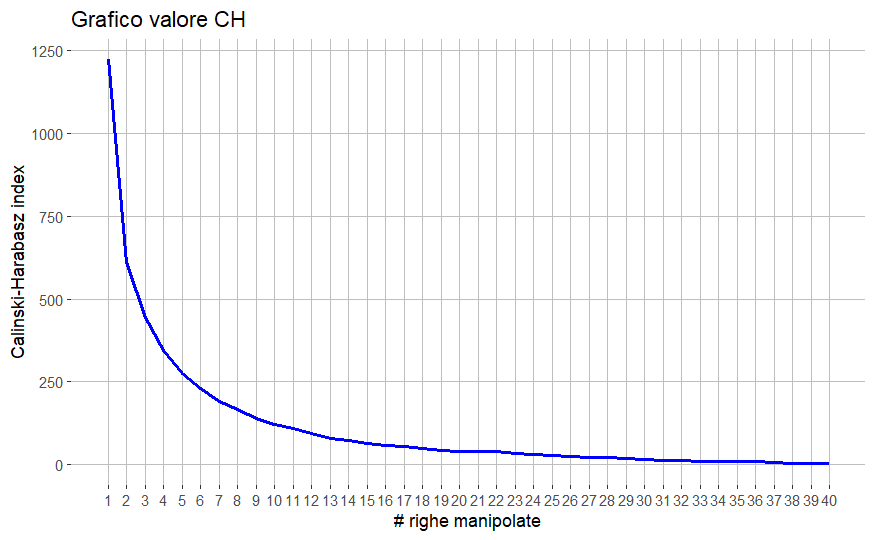

```r
# Creazione del grafico a linee
grafico <- ggplot(data = risultati, aes(x = risultati[,1] , y = risultati[,2])) +
  geom_line(color = "blue", linewidth = 1) +
  ylim(0, max(risultati$valore)) +
  xlim(0, 2*n) +
  theme(panel.grid.major = element_line(color = "grey"), # Aggiunge la griglia principale
        panel.grid.minor = element_blank(), # Rimuove la griglia secondaria
        panel.background = element_blank()) +
  scale_x_continuous(breaks = round(seq(min(risultati$iterazione), max(risultati$iterazione), by = 1), 1)) +
  labs(title = "Grafico valore CH", x = "# righe manipolate", y = "Calinski-Harabasz index")
# Visualizzazione del grafico
print(grafico)
```

verificando come in generale il valore dell’indice di Calinski_Harabasz tende a diminuire ed avvicinarsi allo $0$ con l’aumento delle righe composte da valori compresi tra 0 e 1.